# Dog classifier

###### small proof of concept for Unilabs

This notebook is to provide a simple overview of the process of creating a simple, proof of concept classifier for dogs, specifying different breeds.

We are using a pre-trained model because training a model long enough to be accurate would take too long.

### Index

The notebook is broken into the following steps:

- Step 0: Import Datasets
- Step 1: Detect Humans
- Step 2: Detect Dogs and cats
- Step 3: Use Transfer Learning to create a CNN to classify dog breeds
- Step 4: Final algorithm

## Step 0: Importing datasets

Luckily, the dataset already has the training, test and validation sets properly divided so there is no need to divide it.

```python
import numpy as np
from glob import glob
import re

# load filenames for human and dog images
human_files = np.array(glob("./data/face_images/*/*"))
dog_files = np.array(glob("./data/dog_images/*/*/*"))
cat_files = np.array(glob("./data/cat_images/*/*.jpg")) # Only add the images, and not the special files

# print number of images in each dataset
print('We have %d human images.' % len(human_files))
print('We have %d dog images.' % len(dog_files))
print('We have %d cat images.' % len(cat_files))
```

```
We have 13233 human images.
We have 8351 dog images.
We have 9997 cat images.
```

## Step 1: Detecting Humans

Since we want to also detect humans (in case the user wants to input a picture of a human by mistake), we can make use of OpenCV's implementation for face detection. They have XML files [here](https://github.com/opencv/opencv/tree/master/data/haarcascades) that are used for the classifier to we can use one of these to make use of the algorithm and detect faces on an image.

```python
import cv2

# import face detector
cascade = cv2.CascadeClassifier('./haarcascade_frontalface_alt2.xml')

# function that detects face
def face_detector(path):
    image = cv2.imread(path)
    grayscale = cv2.cvtColor(image, cv2.COLOR_BGR2GRAY)
    detected_faces = cascade.detectMultiScale(grayscale)

    return len(detected_faces) > 0
```

The image is converted to grayscale [per recommendation](https://docs.opencv.org/trunk/db/d28/tutorial_cascade_classifier.html) and the `detectMultiscale` function returns a numpy array of detected faces.

### Assessing if this works

Let's see if it detects human faces accordingly. We'll have the first 100 faces of the human dataset and 100 images of the dog dataset to test if it works. We are expecting the detector to not detect any humans in the dog dataset.

```python
from tqdm import tqdm

human_counter = 0
dog_counter = 0

human_files_100 = human_files[: 100]
dog_files_100 = dog_files[: 100]

for i in range(100):
    is_human_from_human = face_detector(human_files_100[i])
    is_human_from_dogs = face_detector(dog_files_100[i])

    if is_human_from_human is True:
        human_counter += 1

    if is_human_from_dogs is True:
        dog_counter += 1
```

```python
# print integer and float value
print("Percentage of humans in the human dataset: {}%".format(human_counter * 100 / human_files_100.shape[0]))
print("Percentage of humans in the dog dataset: {}%".format(dog_counter * 100 / dog_files_100.shape[0]))
```

```
Percentage of humans in the human dataset: 100.0%
Percentage of humans in the dog dataset: 14.0%
```

## Step 2: Detect Dogs and Cats

To detect if the image is a dog or a cat, we are going to use a pre-trained model. Pytorch has a library of models that we can make use of. For this, we are using a two ResNet models, which uses ImageNet.

This dataset has 1000 classes (targets), which are showcased in this [gist](https://gist.github.com/yrevar/942d3a0ac09ec9e5eb3a).

Let's import the models first.

```python
model_resnet18 = torch.hub.load('pytorch/vision', 'resnet18', pretrained=True)
model_resnet34 = torch.hub.load('pytorch/vision', 'resnet34', pretrained=True)
```

```
Using cache found in /home/luchoturtle/.cache/torch/hub/pytorch_vision_master
Using cache found in /home/luchoturtle/.cache/torch/hub/pytorch_vision_master
```

Let's change the classifier of the ResNet to the output that we want: to know if the image is either a dog or a cat.

```python
# Freeze all params except the BatchNorm layers, as here they are trained to the
# mean and standard deviation of ImageNet and we may lose some signal
for name, param in model_resnet18.named_parameters():
    if("bn" not in name):
        param.requires_grad = False

for name, param in model_resnet34.named_parameters():
    if("bn" not in name):
        param.requires_grad = False
```

```python
# Replace the classifier
num_classes = 2

model_resnet18.fc = nn.Sequential(nn.Linear(model_resnet18.fc.in_features,512),
                                  nn.ReLU(),
                                  nn.Dropout(),
                                  nn.Linear(512, num_classes))

model_resnet34.fc = nn.Sequential(nn.Linear(model_resnet34.fc.in_features,512),
                                  nn.ReLU(),
                                  nn.Dropout(),
                                  nn.Linear(512, num_classes))
```

### Training

Let's define the training function, the testing function and create data loaders and transformations.

```python
import torch
import torch.nn as nn
import torch.optim as optim
import torch.utils.data
import torch.nn.functional as F
import torchvision
import torchvision.models as models
from torchvision import transforms
from PIL import Image
import matplotlib.pyplot as plt

def train(model, optimizer, loss_fn, train_loader, val_loader, epochs=5, device="cpu"):
    for epoch in range(epochs):
        training_loss = 0.0
        valid_loss = 0.0
        model.train()
        for batch in train_loader:
            optimizer.zero_grad()
            inputs, targets = batch
            inputs = inputs.to(device)
            targets = targets.to(device)
            output = model(inputs)
            loss = loss_fn(output, targets)
            loss.backward()
            optimizer.step()
            training_loss += loss.data.item() * inputs.size(0)
        training_loss /= len(train_loader.dataset)

        model.eval()
        num_correct = 0
        num_examples = 0
        for batch in val_loader:
            inputs, targets = batch
            inputs = inputs.to(device)
            output = model(inputs)
            targets = targets.to(device)
            loss = loss_fn(output,targets)
            valid_loss += loss.data.item() * inputs.size(0)

            correct = torch.eq(torch.max(F.softmax(output, dim=1), dim=1)[1], targets).view(-1)
            num_correct += torch.sum(correct).item()
            num_examples += correct.shape[0]
        valid_loss /= len(val_loader.dataset)

        print('Epoch: {}, Training Loss: {:.4f}, Validation Loss: {:.4f}, accuracy = {:.4f}'.format(epoch, training_loss,
        valid_loss, num_correct / num_examples))
```

```python
batch_size=32
img_dimensions = 224

# Normalize to the ImageNet mean and standard deviation
# Could calculate it for the cats/dogs data set, but the ImageNet
# values give acceptable results here.
img_transforms = transforms.Compose([
    transforms.Resize((img_dimensions, img_dimensions)),
    transforms.ToTensor(),
    transforms.Normalize(mean=[0.485, 0.456, 0.406],std=[0.229, 0.224, 0.225] )
    ])

img_test_transforms = transforms.Compose([
    transforms.Resize((img_dimensions,img_dimensions)),
    transforms.ToTensor(),
    transforms.Normalize(mean=[0.485, 0.456, 0.406],std=[0.229, 0.224, 0.225] )
    ])

def check_image(path):
    try:
        im = Image.open(path)
        return True
    except:
        return False

train_data_path = "./data3/train/"
train_data = torchvision.datasets.ImageFolder(root=train_data_path,transform=img_transforms, is_valid_file=check_image)

validation_data_path = "./data3/validation/"
validation_data = torchvision.datasets.ImageFolder(root=validation_data_path,transform=img_test_transforms, is_valid_file=check_image)

test_data_path = "./data3/test/"
test_data = torchvision.datasets.ImageFolder(root=test_data_path,transform=img_test_transforms, is_valid_file=check_image)

num_workers = 6
train_data_loader = torch.utils.data.DataLoader(train_data, batch_size=batch_size, shuffle=True, num_workers=num_workers)
validation_data_loader = torch.utils.data.DataLoader(validation_data, batch_size=batch_size, shuffle=False, num_workers=num_workers)
test_data_loader = torch.utils.data.DataLoader(test_data, batch_size=batch_size, shuffle=False, num_workers=num_workers)


if torch.cuda.is_available():
    device = torch.device("cuda")
else:
    device = torch.device("cpu")
```

```python
print(f'Num training images: {len(train_data_loader.dataset)}')
print(f'Num validation images: {len(validation_data_loader.dataset)}')
print(f'Num test images: {len(test_data_loader.dataset)}')
```

```
Num training images: 16000
Num validation images: 4500
Num test images: 4500
```

```python
def test_model(model):
    correct = 0
    total = 0
    with torch.no_grad():
        for data in test_data_loader:
            images, labels = data[0].to(device), data[1].to(device)
            outputs = model(images)
            _, predicted = torch.max(outputs.data, 1)
            total += labels.size(0)
            correct += (predicted == labels).sum().item()
    print('correct: {:d}  total: {:d}'.format(correct, total))
    print('accuracy = {:f}'.format(correct / total))
```

It's time to train!

```python
model_resnet18.to(device)
optimizer = optim.Adam(model_resnet18.parameters(), lr=0.001)
train(model_resnet18, optimizer, torch.nn.CrossEntropyLoss(), train_data_loader, validation_data_loader, epochs=5, device=device)
```

```
Epoch: 0, Training Loss: 0.0916, Validation Loss: 0.0439, accuracy = 0.9833
Epoch: 1, Training Loss: 0.0515, Validation Loss: 0.0329, accuracy = 0.9871
Epoch: 2, Training Loss: 0.0430, Validation Loss: 0.0370, accuracy = 0.9860
Epoch: 3, Training Loss: 0.0365, Validation Loss: 0.0350, accuracy = 0.9871
Epoch: 4, Training Loss: 0.0322, Validation Loss: 0.0359, accuracy = 0.9844
```

```python
test_model(model_resnet18)
```

```
correct: 4446  total: 4500
accuracy = 0.988000
```

```python
torch.save(model_resnet18.state_dict(), "./model_resnet18.pth")
```

```python
model_resnet34.to(device)
optimizer = optim.Adam(model_resnet34.parameters(), lr=0.001)
train(model_resnet34, optimizer, torch.nn.CrossEntropyLoss(), train_data_loader, validation_data_loader, epochs=5, device=device)
```

```
Epoch: 0, Training Loss: 0.0739, Validation Loss: 0.0315, accuracy = 0.9876
Epoch: 1, Training Loss: 0.0387, Validation Loss: 0.0270, accuracy = 0.9924
Epoch: 2, Training Loss: 0.0266, Validation Loss: 0.0357, accuracy = 0.9873
Epoch: 3, Training Loss: 0.0233, Validation Loss: 0.0316, accuracy = 0.9909
Epoch: 4, Training Loss: 0.0185, Validation Loss: 0.0375, accuracy = 0.9893
```

```python
test_model(model_resnet34)
```

```
correct: 4450  total: 4500
accuracy = 0.988889
```

```python
torch.save(model_resnet34.state_dict(), "./model_resnet34.pth")
```

```python
import os
def find_classes(dir):
    classes = os.listdir(dir)
    classes.sort()
    class_to_idx = {classes[i]: i for i in range(len(classes))}
    return classes, class_to_idx

def make_prediction(model, filename):
    labels, _ = find_classes('./data3/test')
    img = Image.open(filename)
    img = img_test_transforms(img)
    img = img.unsqueeze(0)
    prediction = model(img.to(device))
    prediction = prediction.argmax()
    print(labels[prediction])

make_prediction(model_resnet34, './data3/test/dogs/dog.11460.jpg')
make_prediction(model_resnet34, './data3/test/cats/cat.12262.jpg')
```

```
dogs
cats
```

```python
# Remember that you must call model.eval() to set dropout and batch normalization layers to
# evaluation mode before running inference. Failing to do this will yield inconsistent inference result

resnet18 = torch.hub.load('pytorch/vision', 'resnet18')
resnet18.fc = nn.Sequential(nn.Linear(resnet18.fc.in_features,512),nn.ReLU(), nn.Dropout(), nn.Linear(512, num_classes))
resnet18.load_state_dict(torch.load('./model_resnet18.pth'))
resnet18.eval()

resnet34 = torch.hub.load('pytorch/vision', 'resnet34')
resnet34.fc = nn.Sequential(nn.Linear(resnet34.fc.in_features,512),nn.ReLU(), nn.Dropout(), nn.Linear(512, num_classes))
resnet34.load_state_dict(torch.load('./model_resnet34.pth'))
resnet34.eval()

print("done")
```

```
Using cache found in /home/luchoturtle/.cache/torch/hub/pytorch_vision_master
Using cache found in /home/luchoturtle/.cache/torch/hub/pytorch_vision_master
```

```
done
```

Let's define the function that essentially takes the prediction of the ensemble of both ResNet models and averages them out, to output the predicted label for an image.

```python
models_ensemble = [resnet18.to(device), resnet34.to(device)]

def dog_or_cat_predict(img_path):
    image = Image.open(img_path)

    # These are the transforms according to the documentation in pytorch.models (https://pytorch.org/hub/pytorch_vision_vgg/)
    transform = transforms.Compose([transforms.Resize(img_dimensions),
                                    transforms.CenterCrop(img_dimensions),
                                    transforms.ToTensor(),
                                    transforms.Normalize(mean=[0.485, 0.456, 0.406],
                                                         std=[0.229, 0.224, 0.225])])

    # Apply transforms and add new dimension (to input in the network)
    image_tensor = transform(image).unsqueeze(0)

    # move the input and model to GPU
    image_tensor = image_tensor.to(device)

    with torch.no_grad():

        predictions = [i(image_tensor).data for i in models_ensemble]
        avg_predictions = torch.mean(torch.stack(predictions), dim=0)
        _, predicted = torch.max(avg_predictions, 1)

        return predicted.item() == True
```

### Assessing if this works

Let's see if it detects dogs and cats accordingly. We'll use the same methodology as when we were detecting faces.

```python
human_files_short = human_files[: 100]
iterations = human_files_short.shape[0]

human_counter = 0
dog_counter = 0
cat_counter = 0

human_files_100 = human_files[: 100]
dog_files_100 = dog_files[: 100]
cat_files_100 = cat_files[: 100]

for i in range(iterations):

    if dog_or_cat_predict(cat_files_100[i]):
        dog_counter += 1
    else:
        cat_counter += 1
```

```python
print("Percentage of dogs detected in the dog dataset: {}%".format(dog_counter * 100 / dog_files_100.shape[0]))
print("Percentage of dogs detected in the cat dataset: {}%".format(cat_counter * 100 / cat_files_100.shape[0]))
```

```
Percentage of dogs detected in the dog dataset: 1.0%
Percentage of dogs detected in the cat dataset: 99.0%
```

```python
iterations = human_files_short.shape[0]

human_counter = 0
dog_counter = 0
cat_counter = 0

human_files_100 = human_files[: 100]
dog_files_100 = dog_files[: 100]
cat_files_100 = cat_files[: 100]

for i in range(iterations):

    if cat_detector(human_files_100[i]):
        human_counter += 1

    if cat_detector(cat_files_100[i]):
        cat_counter += 1

    if cat_detector(dog_files_100[i]):
        dog_counter += 1
```

```python
print("Percentage of cats detected in the human dataset: {}%".format(human_counter * 100 / human_files_100.shape[0]))
print("Percentage of cats detected in the dog dataset: {}%".format(dog_counter * 100 / dog_files_100.shape[0]))
print("Percentage of cats detected in the cat dataset: {}%".format(cat_counter * 100 / cat_files_100.shape[0]))
```

[output not shown]

## Step 3: Use Transfer Learning to create a CNN to classify dog breeds

From the datasets that were found, only the dogs had labeled data and had an amount of 133 different breeds. Each folder had various instances of each breed.

Therefore, since we already have implemented a detector for the cats, humans and dogs, it is useful to know which breed it is if a dog is selected. For this, we are using transfer learning to implement a CNN to classify these dog breeds. We could have built a model from scratch but training this would take a while and the accuracy, given the dataset size, would most likely not be satisfactory.

### Data loaders

The dog dataset, as it was previously stated, have each type of set already divided (located at `dog_images/train`, `dog_images/valid`, and `dog_images/test`), which is quite handy. So, for now, let's define the data loaders in which we will iterate the data through whilst training.

```python
import os
import torch
from torchvision import datasets
import torchvision.transforms as transforms

from PIL import ImageFile
ImageFile.LOAD_TRUNCATED_IMAGES = True # Adding this because it fails to train when opening big images

# As per https://pytorch.org/hub/pytorch_vision_vgg/
mean = [0.485, 0.456, 0.406]
std = [0.229, 0.224, 0.225]
batch_size = 32

# Transforms for data augmentation. We are resizing and centering every image at the same number and doing random operations
train_transform = transforms.Compose([transforms.Resize(256),
                                transforms.CenterCrop(256),
                                transforms.RandomHorizontalFlip(),
                                transforms.RandomRotation(15),
                                transforms.ToTensor(),
                                transforms.Normalize(mean = mean, std = std)])

validation_test_transform = transforms.Compose([transforms.Resize(256),
                                transforms.CenterCrop(256),
                                transforms.ToTensor(),
                                transforms.Normalize(mean = mean, std = std)])


# Transformed data
training_data =  datasets.ImageFolder('./data/dog_images/train', transform = train_transform)
validation_data =  datasets.ImageFolder('./data/dog_images/valid', transform = validation_test_transform)
testing_data =  datasets.ImageFolder('./data/dog_images/test', transform = validation_test_transform)



# Data loaders
train_loader = torch.utils.data.DataLoader(training_data, batch_size = batch_size,
                                           shuffle = True)

validation_loader = torch.utils.data.DataLoader(validation_data, batch_size = batch_size,
                                          shuffle = False)

testing_loader = torch.utils.data.DataLoader(testing_data, batch_size = batch_size,
                                         shuffle = False)

# adding this because it is needed afterwards
loaders_transfer = {
    'train': train_loader,
    'valid': validation_loader,
    'test': testing_loader
}
```

### Model Architecture

Since we are using transfer learning, we are going to use an already existing model to train the data in. In this case, we're using ResNet18 to shake things up a bit. According to the [docs](https://pytorch.org/hub/pytorch_vision_resnet/), the model has a final fully connected layer with 512 input classes, so we are appending a classifier of our own at the end of the model to output a prediction to our 133 breeds.

```python
import torchvision.models as models
import torch.nn as nn

model_transfer = models.resnet18(pretrained = True)

# Freeze parameters so we don't backprop through them
for param in model_transfer.parameters():
    param.requires_grad = False

# Define new classifier, two fully connected layers with ReLU activation function and dropout
classifier = nn.Sequential(nn.Linear(512, 256),
                                 nn.ReLU(),
                                 nn.Dropout(0.3),
                                 nn.Linear(256, 133),
                                 nn.LogSoftmax(dim=1))

model_transfer.fc = classifier

# check if CUDA is available
use_cuda = torch.cuda.is_available()

if use_cuda:
    model_transfer = model_transfer.cuda()

print(model_transfer)
```

```
ResNet(
  (conv1): Conv2d(3, 64, kernel_size=(7, 7), stride=(2, 2), padding=(3, 3), bias=False)
  (bn1): BatchNorm2d(64, eps=1e-05, momentum=0.1, affine=True, track_running_stats=True)
  (relu): ReLU(inplace=True)
  (maxpool): MaxPool2d(kernel_size=3, stride=2, padding=1, dilation=1, ceil_mode=False)
  (layer1): Sequential(
    (0): BasicBlock(
      (conv1): Conv2d(64, 64, kernel_size=(3, 3), stride=(1, 1), padding=(1, 1), bias=False)
      (bn1): BatchNorm2d(64, eps=1e-05, momentum=0.1, affine=True, track_running_stats=True)
      (relu): ReLU(inplace=True)
      (conv2): Conv2d(64, 64, kernel_size=(3, 3), stride=(1, 1), padding=(1, 1), bias=False)
      (bn2): BatchNorm2d(64, eps=1e-05, momentum=0.1, affine=True, track_running_stats=True)
    )
    (1): BasicBlock(
      (conv1): Conv2d(64, 64, kernel_size=(3, 3), stride=(1, 1), padding=(1, 1), bias=False)
      (bn1): BatchNorm2d(64, eps=1e-05, momentum=0.1, affine=True, track_running_stats=True)
      (relu): ReLU(inplace=True)
      (conv2): Conv2d(64, 64, kernel_size=(3, 3), stride=(1, 1), padding=(1, 1), bias=False)
      (bn2): BatchNorm2d(64, eps=1e-05, momentum=0.1, affine=True, track_running_stats=True)
    )
  )
  (layer2): Sequential(
    (0): BasicBlock(
      (conv1): Conv2d(64, 128, kernel_size=(3, 3), stride=(2, 2), padding=(1, 1), bias=False)
      (bn1): BatchNorm2d(128, eps=1e-05, momentum=0.1, affine=True, track_running_stats=True)
      (relu): ReLU(inplace=True)
      (conv2): Conv2d(128, 128, kernel_size=(3, 3), stride=(1, 1), padding=(1, 1), bias=False)
      (bn2): BatchNorm2d(128, eps=1e-05, momentum=0.1, affine=True, track_running_stats=True)
      (downsample): Sequential(
        (0): Conv2d(64, 128, kernel_size=(1, 1), stride=(2, 2), bias=False)
        (1): BatchNorm2d(128, eps=1e-05, momentum=0.1, affine=True, track_running_stats=True)
      )
    )
    (1): BasicBlock(
      (conv1): Conv2d(128, 128, kernel_size=(3, 3), stride=(1, 1), padding=(1, 1), bias=False)
      (bn1): BatchNorm2d(128, eps=1e-05, momentum=0.1, affine=True, track_running_stats=True)
      (relu): ReLU(inplace=True)
      (conv2): Conv2d(128, 128, kernel_size=(3, 3), stride=(1, 1), padding=(1, 1), bias=False)
      (bn2): BatchNorm2d(128, eps=1e-05, momentum=0.1, affine=True, track_running_stats=True)
    )
```

[output cut: 35 more lines]

```
      (bn1): BatchNorm2d(512, eps=1e-05, momentum=0.1, affine=True, track_running_stats=True)
      (relu): ReLU(inplace=True)
      (conv2): Conv2d(512, 512, kernel_size=(3, 3), stride=(1, 1), padding=(1, 1), bias=False)
      (bn2): BatchNorm2d(512, eps=1e-05, momentum=0.1, affine=True, track_running_stats=True)
    )
  )
  (avgpool): AdaptiveAvgPool2d(output_size=(1, 1))
  (fc): Sequential(
    (0): Linear(in_features=512, out_features=256, bias=True)
    (1): ReLU()
    (2): Dropout(p=0.3, inplace=False)
    (3): Linear(in_features=256, out_features=133, bias=True)
    (4): LogSoftmax()
  )
)
```

### Loss Function and Optimizer

```python
import torch.optim as optim

criterion_transfer = nn.NLLLoss() # We are returning Softmax so we can use NLLLoss
optimizer_transfer = optim.Adam(model_transfer.fc.parameters(), lr = 0.001)
```

### Training and cross-validating the model

We are first going to define the `train` and `test` functions.

```python
def train(n_epochs, loaders, model, optimizer, criterion, use_cuda, save_path):

    # initialize tracker for minimum validation loss
    valid_loss_min = np.Inf

    for epoch in range(1, n_epochs+1):

        train_loss = 0.0
        valid_loss = 0.0

        ###################
        # train the model #
        ###################
        model.train()
        for batch_idx, (data, target) in enumerate(loaders['train']):

            if use_cuda:
                data, target = data.cuda(), target.cuda()

            optimizer.zero_grad()

            output = model(data)
            loss = criterion(output, target)

            loss.backward()
            optimizer.step()

            train_loss = train_loss + ((1 / (batch_idx + 1)) * (loss.data - train_loss))

        ######################
        # validate the model #
        ######################
        model.eval()
        for batch_idx, (data, target) in enumerate(loaders['valid']):

            if use_cuda:
                data, target = data.cuda(), target.cuda()

            ## update the average validation loss
            output = model(data)
            loss = criterion(output, target)
            valid_loss = valid_loss + ((1 / (batch_idx + 1)) * (loss.data - valid_loss))

        # print training/validation statistics
        print('Epoch: {} \tTraining Loss: {:.6f} \tValidation Loss: {:.6f}'.format(
            epoch,
            train_loss,
            valid_loss
            ))

        ## save the model if validation loss has decreased
        if valid_loss < valid_loss_min:
            print('Validation loss decreased ({:.6f} --> {:.6f}).  Saving model ...'.format(
                    valid_loss_min,
                    valid_loss))

            torch.save(model.state_dict(), save_path)

            valid_loss_min = valid_loss

    # return trained model
    return model
```

```python
def test(loaders, model, criterion, use_cuda):

    test_loss = 0.
    correct = 0.
    total = 0.

    model.eval()
    for batch_idx, (data, target) in enumerate(loaders['test']):

        if use_cuda:
            data, target = data.cuda(), target.cuda()

        output = model(data)

        loss = criterion(output, target)

        test_loss = test_loss + ((1 / (batch_idx + 1)) * (loss.data - test_loss))

        # convert output probabilities to predicted class
        pred = output.data.max(1, keepdim=True)[1]

        # compare predictions to true label
        correct += np.sum(np.squeeze(pred.eq(target.data.view_as(pred))).cpu().numpy())
        total += data.size(0)

    print('Test Loss: {:.6f}\n'.format(test_loss))

    print('\nTest Accuracy: %2d%% (%2d/%2d)' % (
        100. * correct / total, correct, total))
```

```python
import numpy as np

# train the model
model_transfer = train(20, loaders_transfer, model_transfer, optimizer_transfer, criterion_transfer, use_cuda, 'saved_model.pt')
```

```
Epoch: 1 	Training Loss: 3.406643 	Validation Loss: 1.593467
Validation loss decreased (inf --> 1.593467).  Saving model ...
Epoch: 2 	Training Loss: 1.534135 	Validation Loss: 0.963657
Validation loss decreased (1.593467 --> 0.963657).  Saving model ...
Epoch: 3 	Training Loss: 1.148446 	Validation Loss: 0.817193
Validation loss decreased (0.963657 --> 0.817193).  Saving model ...
Epoch: 4 	Training Loss: 0.983536 	Validation Loss: 0.659267
Validation loss decreased (0.817193 --> 0.659267).  Saving model ...
Epoch: 5 	Training Loss: 0.863146 	Validation Loss: 0.624782
Validation loss decreased (0.659267 --> 0.624782).  Saving model ...
Epoch: 6 	Training Loss: 0.804699 	Validation Loss: 0.600859
Validation loss decreased (0.624782 --> 0.600859).  Saving model ...
Epoch: 7 	Training Loss: 0.769874 	Validation Loss: 0.667154
Epoch: 8 	Training Loss: 0.738838 	Validation Loss: 0.616647
Epoch: 9 	Training Loss: 0.684533 	Validation Loss: 0.584539
Validation loss decreased (0.600859 --> 0.584539).  Saving model ...
Epoch: 10 	Training Loss: 0.677957 	Validation Loss: 0.574315
Validation loss decreased (0.584539 --> 0.574315).  Saving model ...
Epoch: 11 	Training Loss: 0.649293 	Validation Loss: 0.581215
Epoch: 12 	Training Loss: 0.611546 	Validation Loss: 0.565754
Validation loss decreased (0.574315 --> 0.565754).  Saving model ...
Epoch: 13 	Training Loss: 0.593454 	Validation Loss: 0.552070
Validation loss decreased (0.565754 --> 0.552070).  Saving model ...
Epoch: 14 	Training Loss: 0.587605 	Validation Loss: 0.554334
Epoch: 15 	Training Loss: 0.575479 	Validation Loss: 0.543820
Validation loss decreased (0.552070 --> 0.543820).  Saving model ...
Epoch: 16 	Training Loss: 0.563923 	Validation Loss: 0.543896
Epoch: 17 	Training Loss: 0.550985 	Validation Loss: 0.557722
Epoch: 18 	Training Loss: 0.519767 	Validation Loss: 0.534084
Validation loss decreased (0.543820 --> 0.534084).  Saving model ...
Epoch: 19 	Training Loss: 0.510787 	Validation Loss: 0.569850
Epoch: 20 	Training Loss: 0.551401 	Validation Loss: 0.552338
```

### Testing the model

After having trained the model and saved the checkpoints everytime the cross-validation loss went down, it is about time to load up the saved model and test it!

```python
# load the model that got the best validation accuracy
model_transfer.load_state_dict(torch.load('saved_model.pt'))
```

```
<All keys matched successfully>
```

```python
test(loaders_transfer, model_transfer, criterion_transfer, use_cuda)
```

```
Test Loss: 0.599142


Test Accuracy: 80% (675/836)
```

Alright, the accuracy is pretty average but it will suffice for what we are trying to showcase.

### Function to predict the dog breed with our model

Now that we have a function that returns the prediction between our 133 dog breeds, let's create a function that given an image, it returns the breed.

```python
class_names = [item[4:].replace("_", " ") for item in loaders_transfer['train'].dataset.classes]
print(class_names)
```

[output not shown]

```python
from PIL import Image

# The folders have the following pattern "001.American_Eskimo_Dog"
# Here we are just replacing the names and tossing them to a list with each breed (class)
class_names = [item[4:].replace("_", " ") for item in loaders_transfer['train'].dataset.classes]

def predict_breed(model, img_path):

    image = Image.open(img_path)

    mean = [0.485, 0.456, 0.406]
    std = [0.229, 0.224, 0.225]

    # Declaring transforms and normalizing according to the documentation
    transform = transforms.Compose([transforms.Resize(256),
                                    transforms.CenterCrop(256),
                                    transforms.ToTensor(),
                                    transforms.Normalize(mean = mean, std = std)])

    # discard the transparent, alpha channel and adding dimension (just as in the VGG prediction)
    image = transform(image)[:3,:,:].unsqueeze(0)

    model = model.to("cpu")    # changed to CPU because of it is expecting a floattensor, not a cuda.floattensor
    model.eval()
    idx = torch.argmax(model(image)) # the index with the highest prediction

    return class_names[idx]
```

## Step 4: Final algorithm

Now that we have a way to detect human, dogs and cats AND a way, if given an image of a dog, to provide information about its most likely breed, we can join all of these together into an algorithm that, when presented with an image, it returns useful information!

```python
import matplotlib.pyplot as plt
%matplotlib inline
import cv2
from PIL import Image

def detect_image(img_path):
    img = Image.open(img_path)

    plt.imshow(img)
    plt.show()

    if face_detector(img_path) is True:
        print("There is a human in this photo.")

    elif dog_or_cat_predict(img_path) is True:
        pred = predict_breed(model_transfer, img_path)
        print("This is a dog and I think that it is a {0}".format(pred))

    else:
        print("It is not a dog nor a human, it is a cat!")
```

### Testing on a few images

[figure not shown]

```
This is a dog and I think that it is a Chow chow
```

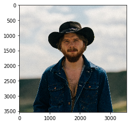

```
There is a human in this photo.
```

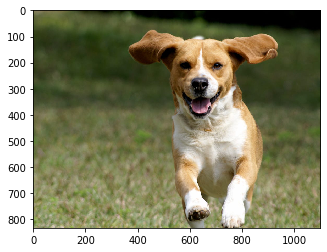

```
This is a dog and I think that it is a Pointer
```

[figure not shown]

```
It is not a dog nor a human, it is a cat!
```

```python
sample_images = np.array(glob("sample_images/*"))

for file in np.hstack(sample_images):
    detect_image(file)
```